# Preliminary Results

Juliana Balluffi-Fry

2026-09-18

Results

General Summary

Tables

Table 1. Sample size of juveniles, litters, and female red squirrels and the years of those sample sizes, by grid and grid-treatment.

| Grid | Grid_treatment | N_juveniles | N_litters | N_females | Years |
| --- | --- | --- | --- | --- | --- |
| KL | Control | 2214 | 720 | 415 | 1989-2025 |
| SU | Control | 1461 | 490 | 290 | 1989-2025 |
| LL | Food add | 506 | 142 | 90 | 2006-2011 |
| JO | Food add | 460 | 129 | 85 | 2007-2012 |
| AG | Food add | 1387 | 436 | 257 | 2005-2017 |
| AG | Rattle | 15 | 4 | 4 | 2010-2010 |
| JO | Rattle | 150 | 47 | 41 | 2018-2022 |
| BT | Control | 38 | 12 | 12 | 2010-2021 |
| LL | Rattle | 45 | 11 | 11 | 2010-2010 |
| BT | Rattle | 14 | 4 | 4 | 2010-2010 |

Control Model

|  | growthrate_std |  | littersize_std |  |
| --- | --- | --- | --- | --- |
| Predictors | Estimates | CI (95%) | Estimates | CI (95%) |
| Intercept | 0.08 | -0.03 – 0.19 | -0.06 | -0.17 – 0.05 |
| density std | 0.00 | -0.06 – 0.06 | -0.04 | -0.10 – 0.02 |
| cones std | -0.00 | -0.06 – 0.05 | 0.01 | -0.05 – 0.07 |
| mother age std | -0.10 | -0.15 – -0.04 | 0.03 | -0.03 – 0.09 |
| bjulian std | -0.14 | -0.19 – -0.08 | -0.05 | -0.11 – 0.01 |
| mast: yes | -0.03 | -0.20 – 0.14 | -0.00 | -0.18 – 0.17 |
| sexratio | -0.15 | -0.32 – 0.02 | 0.10 | -0.08 – 0.28 |
| N <sub>gridyear</sub> | 73 |  |  |  |
| N <sub>mother_byear</sub> | 39 |  |  |  |
| Observations | 1193 |  |  |  |

Food Model

|  | growthrate_std |  | littersize_std |  |
| --- | --- | --- | --- | --- |
| Predictors | Estimates | CI (95%) | Estimates | CI (95%) |
| Intercept | 0.06 | -0.09 – 0.21 | -0.08 | -0.23 – 0.06 |
| treatment_indNoBucket | -0.13 | -0.30 – 0.05 | 0.06 | -0.11 – 0.24 |
| treatment ind: Bucket | 0.11 | -0.03 – 0.26 | 0.05 | -0.09 – 0.19 |
| density std | -0.05 | -0.15 – 0.05 | -0.05 | -0.15 – 0.05 |
| cones std | 0.03 | -0.04 – 0.10 | 0.03 | -0.04 – 0.10 |
| mother age std | -0.02 | -0.08 – 0.04 | 0.07 | 0.01 – 0.13 |
| bjulian std | -0.17 | -0.23 – -0.11 | -0.10 | -0.16 – -0.04 |
| mast: yes | 0.01 | -0.15 – 0.17 | -0.03 | -0.19 – 0.13 |
| sexratio | -0.19 | -0.39 – -0.01 | 0.16 | -0.03 – 0.35 |
| treatment_indNoBucket:density_std | 0.12 | -0.03 – 0.27 | -0.06 | -0.22 – 0.09 |
| treatment_indBucket:density_std | 0.02 | -0.13 – 0.16 | -0.08 | -0.23 – 0.06 |
| N <sub>gridyear</sub> | 51 |  |  |  |
| N <sub>mother_byear</sub> | 19 |  |  |  |
| Observations | 1178 |  |  |  |

Cache Model

|  | growthrate_std |  | littersize_std |  |
| --- | --- | --- | --- | --- |
| Predictors | Estimates | CI (95%) | Estimates | CI (95%) |
| Intercept | 0.14 | -0.11 – 0.39 | -0.17 | -0.42 – 0.10 |
| cache cat: medium | 0.03 | -0.20 – 0.25 | -0.00 | -0.23 – 0.23 |
| cache cat: large | 0.00 | -0.26 – 0.27 | 0.01 | -0.26 – 0.28 |
| density std | -0.18 | -0.43 – 0.07 | 0.13 | -0.13 – 0.38 |
| cones std | -0.00 | -0.09 – 0.09 | -0.04 | -0.12 – 0.06 |
| mother age std | -0.05 | -0.16 – 0.06 | -0.03 | -0.14 – 0.08 |
| bjulian std | -0.16 | -0.26 – -0.06 | -0.09 | -0.19 – 0.00 |
| mast: yes | -0.03 | -0.36 – 0.29 | 0.02 | -0.31 – 0.35 |
| sexratio | -0.28 | -0.57 – 0.01 | 0.23 | -0.06 – 0.53 |
| cache_catmedium:density_std | 0.16 | -0.12 – 0.44 | -0.05 | -0.33 – 0.24 |
| cache_catlarge:density_std | 0.22 | -0.08 – 0.53 | -0.15 | -0.46 – 0.15 |
| N <sub>gridyear</sub> | 34 |  |  |  |
| N <sub>mother_byear</sub> | 21 |  |  |  |
| Observations | 452 |  |  |  |

Rattle Model

|  | growthrate_std |  | littersize_std |  |
| --- | --- | --- | --- | --- |
| Predictors | Estimates | CI (95%) | Estimates | CI (95%) |
| Intercept | -0.00 | -0.35 – 0.35 | 0.14 | -0.20 – 0.48 |
| treatment gr: Rattle | -0.09 | -0.48 – 0.30 | -0.13 | -0.52 – 0.25 |
| density std | 0.02 | -0.21 – 0.26 | -0.08 | -0.33 – 0.16 |
| cones std | -0.02 | -0.19 – 0.16 | -0.02 | -0.18 – 0.15 |
| bjulian std | 0.04 | -0.10 – 0.17 | -0.14 | -0.27 – -0.00 |
| mast: yes | -0.09 | -0.50 – 0.31 | -0.13 | -0.53 – 0.27 |
| sexratio | 0.08 | -0.35 – 0.52 | -0.26 | -0.69 – 0.17 |
| treatment_grRattle:density_std | -0.07 | -0.53 – 0.38 | -0.31 | -0.76 – 0.13 |
| N <sub>gridyear</sub> | 21 |  |  |  |
| N <sub>mother_byear</sub> | 17 |  |  |  |
| Observations | 224 |  |  |  |

Figure Captions

Figure 2. Raw data from control grids (n = 1198) showing the overall negative trade-off between litter size and litter growth rate (g/day). Linear relationship is shown.

Figure 4. Predictions of the covariance (left column) and correlation (right column) between litter growth rate (GR) and litter size (LS) in response to local density based on three Bayesian models: Food model (top row), Cache model (middle row), and Rattle model (bottom row). Each model tested a different scenario or experiment. The Food model (n = 1178) tested how the interaction between a mother’s local density and her food treatment (control = grey, food add grid with a bucket = red, food add grid with no bucket = blue) affects the relationship between litter growth rate and litter size. The Cache model (n = 454) tested how the interaction between a mother’s local density and her cache size in the previous autumn (small = yellow, medium = light green, large = dark green) affects the relationship between litter growth rate and litter size. The Rattle model (n = 238) tested how the interaction between a mother’s local density and her perceived density treatment (control = grey, rattle playback = violet) affects the relationship between litter growth rate and litter size.

Figure 5. Linear predictions for litter growth rate (top row) and litter size (bottom row), separately, in response to local density based on four Bayesian models: A) Control model, B) Food model, C) Cache model, and D) Rattle model. Each model tested a different scenario or experiment, with the control model (A) being the base model. B) Predictions from the Food model (n = 1178) tested how the interaction between a mother’s local density and her food treatment (control = grey, food add grid with a bucket = red, food add grid with no bucket = blue) affects the relationship between litter growth rate and litter size. C) Predictions from the Cache model (n = 454) that tested how the interaction between a mother’s local density and her cache size in the previous autumn (small = yellow, medium = light green, large = dark green) affects the relationship between litter growth rate and litter size. D) Predictions from the Rattle model (n = 238) that tested how the interaction between a mother’s local density and her perceived density treatment (control = grey, rattle playback = violet) affects the relationship between litter growth rate and litter size.

Figures

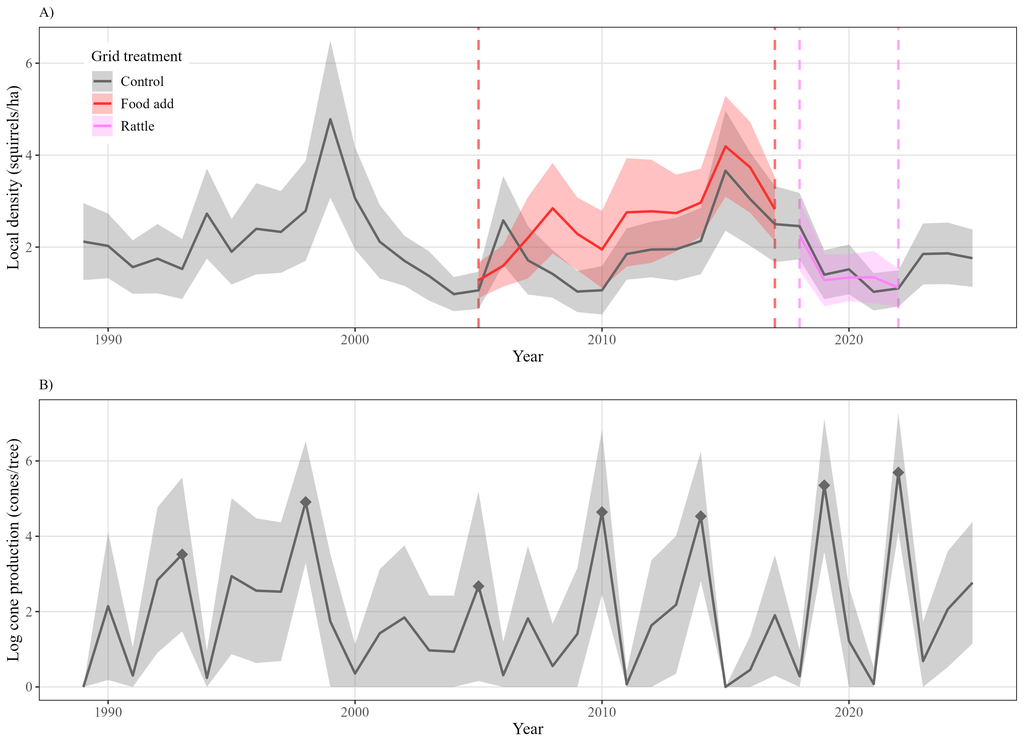

Figure 1

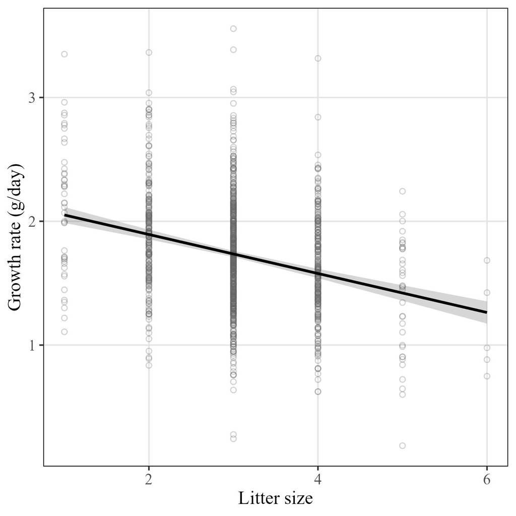

Figure 2

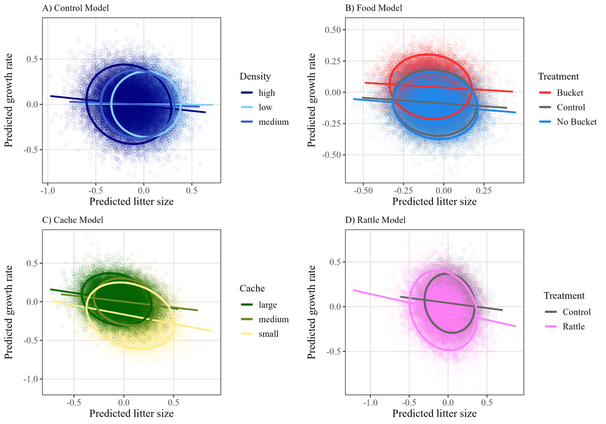

Figure 3

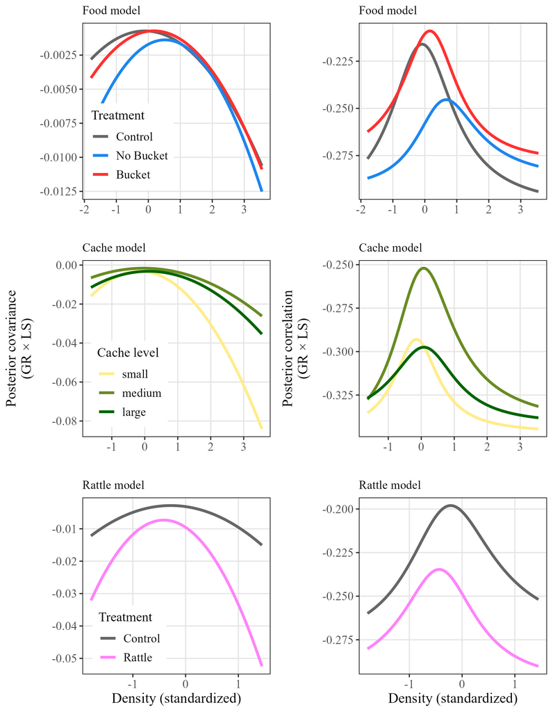

Figure 4

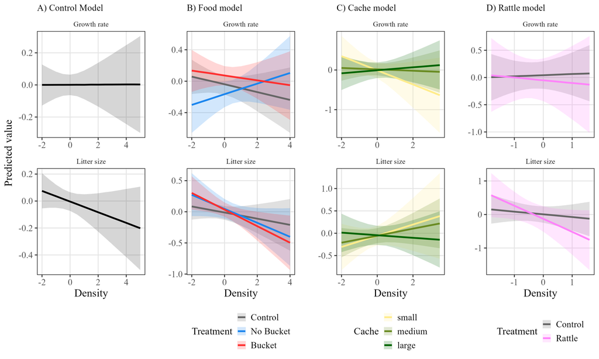

Figure 5.

Supplementary Information

Supplementary Table 1. Sample size of juveniles, litters, and female red squirrels, by year, grid, and grid-treatment from 2010 - 2022.

| Year | Grid | Grid_treatment | N_juveniles | N_litters | N_females |
| --- | --- | --- | --- | --- | --- |
| 2010 | AG | Food add | 60 | 16 | 16 |
| 2010 | JO | Food add | 79 | 20 | 20 |
| 2010 | SU | Control | 31 | 8 | 8 |
| 2010 | AG | Rattle | 15 | 4 | 4 |
| 2010 | KL | Control | 37 | 10 | 10 |
| 2010 | LL | Food add | 49 | 13 | 13 |
| 2010 | LL | Rattle | 45 | 11 | 11 |
| 2010 | BT | Rattle | 14 | 4 | 4 |
| 2010 | BT | Control | 4 | 1 | 1 |
| 2011 | AG | Food add | 64 | 20 | 20 |
| 2011 | LL | Food add | 52 | 15 | 15 |
| 2011 | KL | Control | 47 | 13 | 13 |
| 2011 | JO | Food add | 29 | 9 | 9 |
| 2011 | SU | Control | 14 | 4 | 4 |
| 2012 | AG | Food add | 77 | 23 | 23 |
| 2012 | KL | Control | 104 | 33 | 33 |
| 2012 | JO | Food add | 72 | 20 | 20 |
| 2012 | SU | Control | 49 | 17 | 17 |
| 2013 | KL | Control | 90 | 31 | 31 |
| 2013 | AG | Food add | 128 | 41 | 41 |
| 2013 | SU | Control | 54 | 19 | 19 |
| 2014 | SU | Control | 36 | 12 | 12 |
| 2014 | AG | Food add | 143 | 42 | 42 |
| 2014 | KL | Control | 79 | 21 | 21 |
| 2015 | KL | Control | 100 | 33 | 33 |
| 2015 | SU | Control | 55 | 19 | 19 |
| 2015 | AG | Food add | 127 | 44 | 44 |
| 2016 | KL | Control | 79 | 33 | 33 |
| 2016 | AG | Food add | 85 | 30 | 30 |
| 2016 | SU | Control | 31 | 13 | 13 |
| 2017 | SU | Control | 53 | 20 | 20 |
| 2017 | AG | Food add | 177 | 59 | 59 |
| 2017 | KL | Control | 111 | 39 | 39 |
| 2018 | JO | Rattle | 53 | 20 | 20 |
| 2018 | KL | Control | 102 | 37 | 37 |
| 2018 | SU | Control | 40 | 15 | 15 |
| 2018 | BT | Control | 12 | 4 | 4 |
| 2019 | SU | Control | 14 | 3 | 3 |
| 2019 | JO | Rattle | 17 | 5 | 5 |
| 2019 | KL | Control | 50 | 11 | 11 |
| 2019 | BT | Control | 7 | 2 | 2 |
| 2020 | KL | Control | 54 | 15 | 15 |
| 2020 | JO | Rattle | 34 | 10 | 10 |
| 2020 | SU | Control | 12 | 4 | 4 |
| 2020 | BT | Control | 9 | 3 | 3 |
| 2021 | SU | Control | 15 | 5 | 5 |
| 2021 | KL | Control | 49 | 17 | 17 |
| 2021 | JO | Rattle | 12 | 4 | 4 |
| 2021 | BT | Control | 6 | 2 | 2 |
| 2022 | JO | Rattle | 34 | 8 | 8 |
| 2022 | KL | Control | 36 | 7 | 7 |
| 2022 | SU | Control | 18 | 5 | 5 |

S2. Summary of density and life history outcomes in response to treatments (n = 2064). A) Local densities (ind/ha) of red squirrels in response to treatment at the grid level, where grids housed either food-add experiments, rattle playback experiments, or were controls. B) Litter growth rate (g/day) and C) litter size in response to treatment of the mother. Females were subject to one of five treatment types: natural conditions (Control), controls for playback experiment (Chickadee playbacks), treatments for playback experiment (Rattle playbacks), controls on food add grids (No Bucket), or treatments on food add grids (Bucket).

S3. Best linear unbiased predictors from the rattle model with chickadee playback mothers tested as a separate treatment group.

S4. Linear model predictions for the relationship between squirrel litter growth rate (g/day) and litter size as an interaction with three categories of squirrel density (low = red, medium = green, and high = blue). Left column: results from four different models, each using data subset to a different experimental treatment, controls (n = 1267), buckets (n = 479), no buckets (n = 228), and rattles (n = 66). Right column: results from one model that used all litters with cache size data (n = 454) and interacted litter size with density and the mother’s cache size (categorical, either small, medium, or large).

S5. Predictions for all fixed effects from the control model which did not include any interacting term with density. Litters used in this model were from control grids across all years, and the model did not test for any effect of cache size.

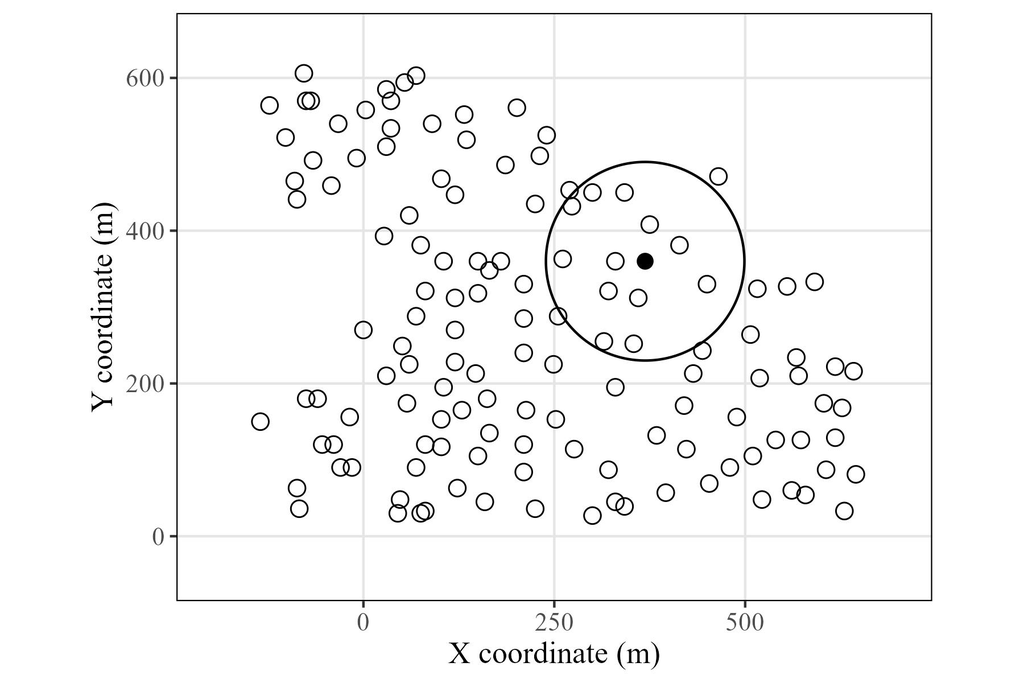

S1

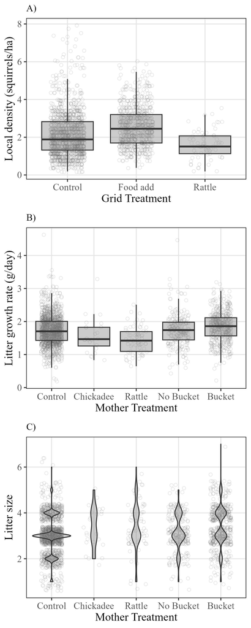

S2

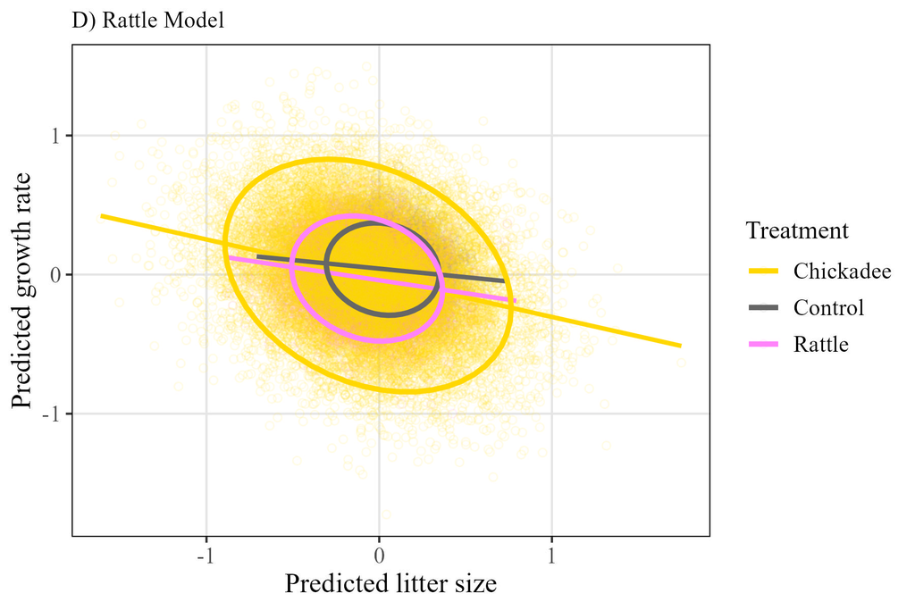

S3

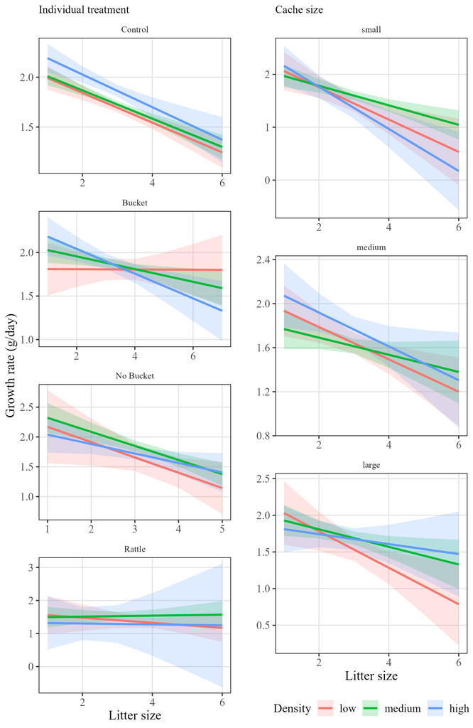

S4

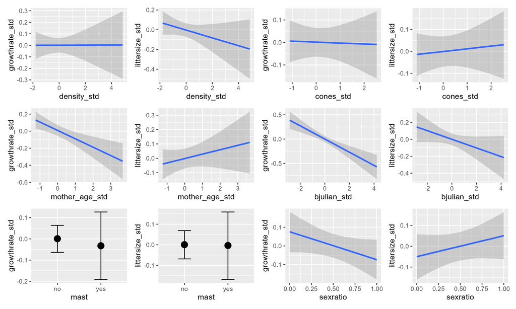

S5

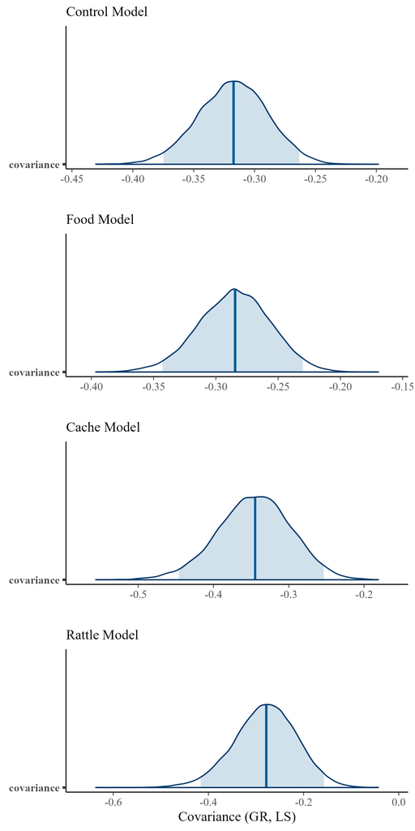

S6